# Assignment 1 DATA2002

Author

520641008

Published

September 6, 2023

```css
body {
  font-size: 0.9em;  /* Adjust this value as needed */
}

.caption-style{
  color: grey;        /* sets the text color to grey */
  font-size: 0.8em;   /* reduces the font size to 80% of the current size */
  display: block;     /* makes the span take up the full width like a block element */
  text-align: center; /* centers the caption text */
}
```

## 1 Introduction

There are concerns regarding the phrasing of certain survey questions, which could lead to bias or misinterpretation by respondents. For example, the question, “Do you tend to lean towards saying ‘yes’ or towards saying ‘no’ to things throughout life?” introduces ambiguity because of the vague reference to “things.” and having the responses limited to only “yes” or “no” raises some bias. Additionally, the questions about height and the interval between haircuts allowed any form of response. This unrestricted format could lead to inconsistencies in the data if students provide answers in unexpected units or formats. Ideally, responses should have been limited to numerical inputs, and specifications should have been given for whether height should be in metric or imperial units.

### 1.1 Data Wrangling

```r
x = readr::read_csv("Assignment_Survey.csv")
old_names = colnames(x)
new_names = c("timestamp","n_units","task_approach","age",
              "life","fass_unit","fass_major","novel",
              "library","private_health","sugar_days","rent",
              "post_code","haircut_days","laptop_brand",
              "urinal_position","stall_position","n_weetbix","food_budget",
              "pineapple","living_arrangements","height","uni_travel_method",
              "feel_anxious","study_hrs","work","social_media",
              "gender","sleep_time","diet","random_number",
              "steak_preference","dominant_hand","normal_advanced","exercise_hrs",
              "employment_hrs","on_time","used_r_before","team_role",
              "social_media_hrs","uni_year","sport","wam","shoe_size")
# overwrite the old names with the new names:
colnames(x) = new_names
# combine old and new into a data frame:
name_combo = bind_cols(New = new_names, Old = old_names)
name_combo |> gt::gt()

x = x |>
  dplyr::mutate(
    height_clean = readr::parse_number(height),
    height_clean = case_when(
      # convert meters to cm
      height_clean <= 2.5 ~ height_clean * 100,
      # convert the feet and inches to missing
      height_clean <= 9 ~ NA_real_,
      # convert inches to cm
      height_clean < 90 ~ height_clean * 2.54,
      TRUE ~ height_clean
    )
  )
x = x |>
  mutate(height_clean = if_else(height_clean>100, height_clean, NA ))
# check it's worked:
# x |> select(height, height_clean) |> View()
x= x |> mutate(
  social_media_clean = tolower(social_media),
  social_media_clean = str_replace_all(social_media_clean, '[[:punct:]]',' '),
  social_media_clean = stringr::word(social_media_clean),
  social_media_clean = case_when(
    stringr::str_starts(social_media_clean,"in") ~ "instagram",
    stringr::str_starts(social_media_clean,"ig") ~ "instagram",
    stringr::str_starts(social_media_clean,"tik") ~ "tiktok",
    stringr::str_starts(social_media_clean,"we") ~ "wechat",
    stringr::str_starts(social_media_clean,"x") ~ "twitter",
    stringr::str_starts(social_media_clean,"mess") ~ "facebook",
    stringr::str_starts(social_media_clean,"bil") ~ "bilibili",
    is.na(social_media_clean) ~ "none",
    TRUE ~ social_media_clean
  ),
  social_media_clean = tools::toTitleCase(social_media_clean),
  social_media_clean = forcats::fct_lump_min(social_media_clean, min = 10)
)

x = x |>
  mutate(identifier = row_number()) |>
  mutate(sport = replace_na(sport, "I don't play any sport"))

sport <- x |>
  dplyr::select(identifier, sport) |>
  tidyr::separate_rows(sport,
                       sep = ", ") |>
  dplyr::mutate(sport = tools::toTitleCase(sport),
                sport = factor(sport),
                sport = forcats::fct_lump_min(sport, 2))

sport_wide = sport |>
  mutate(value = 1) |>
  distinct() |>
  pivot_wider(id_cols = identifier,
              names_from = sport,
              values_from = value,
              values_fill = 0)

x = x |>
  left_join(sport_wide, by = "identifier") |>
  janitor::clean_names()
colnames(x)

# Cleaning Data for Section 2.1
anxious_vector = x$feel_anxious
gender_vector = x$gender
anxious_gender_df = data.frame(gender_vector, anxious_vector)
anxious_gender_df = na.omit(anxious_gender_df)

# Convert to lowercase
anxious_gender_df$gender_vector <- tolower(anxious_gender_df$gender_vector)

# Standardize male and female entries
anxious_gender_df$gender_vector[anxious_gender_df$gender_vector %in% c("male", "m", "man", "heterosexual male", "mothman")] <- "male"
anxious_gender_df$gender_vector[anxious_gender_df$gender_vector %in% c("female", "f", "woman", "women","femal")] <- "female"

# Filter out unwanted values
unwanted_values = c("non-binary", "pansexual", "n/a", "i dont want to answer this.")


anxious_gender_df <- anxious_gender_df %>%
    filter(!(gender_vector %in% unwanted_values))

anxious_gender_df

anxious_gender_df$anxious_vector[anxious_gender_df$anxious_vector %in% c(1, 2, 3)] <- "1-3"
anxious_gender_df$anxious_vector[anxious_gender_df$anxious_vector %in% c(4, 5, 6, 7)] <- "4-7"
anxious_gender_df$anxious_vector[anxious_gender_df$anxious_vector %in% c(8, 9, 10)] <- "8-10"

anxious_gender_table <- table(anxious_gender_df)
# Cleaning Data for Section 2.2
# Using more descriptive column names
gender_vector_2 = x$gender
sleep_vector = x$sleep_time

gender_sleep_df = data.frame(gender = gender_vector_2, sleep = sleep_vector)
gender_sleep_df = na.omit(gender_sleep_df)

# Convert all gender values to lowercase
gender_sleep_df$gender <- tolower(gender_sleep_df$gender)

# Standardize male and female entries
gender_sleep_df$gender[gender_sleep_df$gender %in% c("male", "m", "man", "heterosexual male", "mothman")] <- "male"
gender_sleep_df$gender[gender_sleep_df$gender %in% c("female", "f", "woman", "women", "femal")] <- "female"

# Filter out unwanted values
unwanted_values = c("non-binary", "pansexual", "n/a", "i dont want to answer this.")
gender_sleep_df <- gender_sleep_df %>%
    filter(!(gender %in% unwanted_values))

# Cleaning function
clean_sleep <- function(sleep) {
  sleep_cleaned <- str_replace_all(sleep, " hours|hrs| hrs|hr|h/day|h", "")

  if(str_detect(sleep_cleaned, "-")){
    nums_split = strsplit(sleep_cleaned,"-")
    nums = as.numeric(unlist(nums_split))
    return(mean(nums))
  } else{
    return(as.numeric(sleep_cleaned))
  }
}

gender_sleep_df$sleep = sapply(gender_sleep_df$sleep, clean_sleep)
gender_sleep_df = na.omit(gender_sleep_df)
gender_sleep_df <- gender_sleep_df[gender_sleep_df$sleep != 6000.0, ]
males <- gender_sleep_df %>%
  filter(gender == "male") %>%
  pull(sleep)

females <- gender_sleep_df %>%
  filter(gender == "female") %>%
  pull(sleep)

#Cleaning data for 2.3
raw_anxious_vector = x$feel_anxious
raw_exercise_vector = x$exercise_hrs
anxious_vector_df = data.frame(anxious = raw_anxious_vector, exercise = raw_exercise_vector)
anxious_vector_df = na.omit(anxious_vector_df)

anxious_vector_df$anxious[anxious_vector_df$anxious %in% c(1, 2, 3,4,5)] <- "low"
anxious_vector_df$anxious[anxious_vector_df$anxious %in% c(4, 5, 6, 7,8,9,10)] <- "high"


anxious_vector_df <- anxious_vector_df %>% filter(exercise!=150)
```

## 2 Results

### 2.1 Are anxiety levels independent of gender at the p < 0.05 significance level

In figure-1, we can see that the proportion of each level of anxiety of male vs female seems roughly equal with a slight skewness into males. To test if this skewness is significant at a significance level of 0.05, we shall conduct a Chi-square test of independence to check if anxiety and gender is independent of each other.

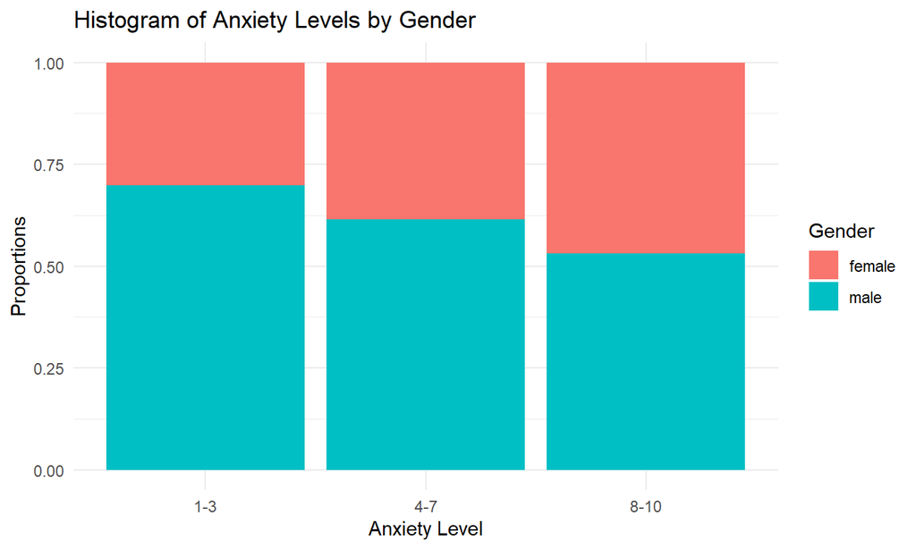

```r
bar_plot <- ggplot(anxious_gender_df, aes(x = anxious_vector, fill = gender_vector)) +
  geom_bar(position = "fill") +
  labs(title = "Histogram of Anxiety Levels by Gender",
       x = "Anxiety Level",
       y = "Proportions",
       fill = "Gender") +
  #scale_fill_manual(values = c("pink", "blue")) + # Assuming you have two gender categories: male and female
  theme_minimal()
bar_plot
```

Figure 1. Histogram of the proportions of male to female regarding their anxiety levels split into low (1-3), medium (4-7), and high(8-10)

```r
res = chisq.test(anxious_gender_table)
res$expected = round(res$expected, 2)
# Rearrange the columns
knitr::kable(res$expected)
```

|  | 1-3 | 4-7 | 8-10 |
| --- | --- | --- | --- |
| female | 28 | 58.68 | 25.32 |
| male | 45 | 94.32 | 40.68 |

Table 1. Table of the expected counts obtained from the chi-squared test

### 2.2 Is there a Significant difference at p < 0.05 between the mean of males and females for how many hours of sleep they get?

In Figure 2, we have a histogram showing that the sleep hours among the genders shows a somewhat normal distribution and in Table 2 we can see that the mean and standard deviation of the males and females are somwhat similar. To test if the mean of hours slept in males and females are significantly different we will conduct a two-sample t-test.

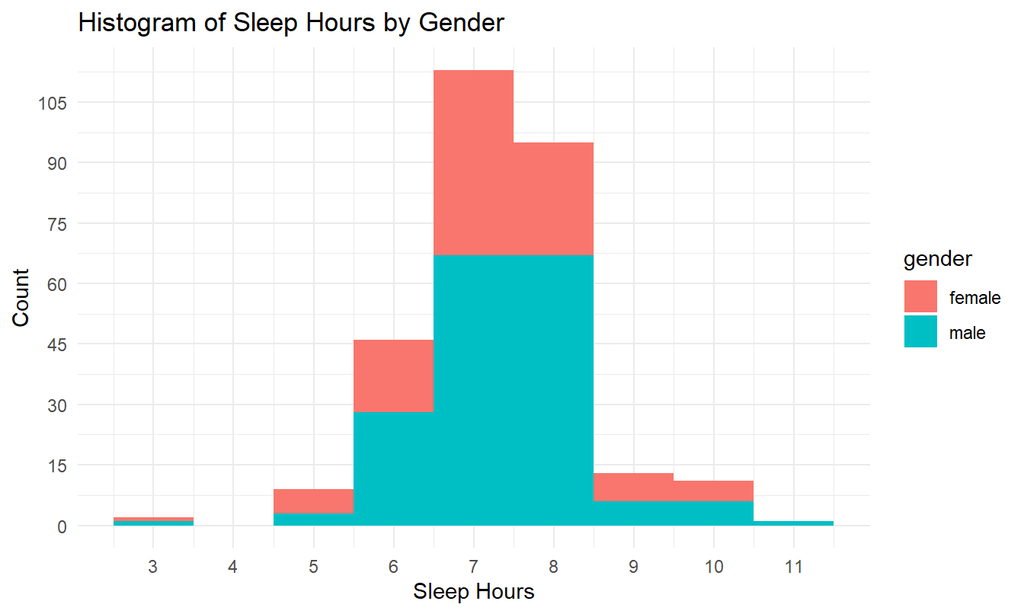

```r
ggplot(gender_sleep_df, aes(x=sleep, fill=gender)) +
  geom_histogram(binwidth = 1) +
  labs(title="Histogram of Sleep Hours by Gender", x="Sleep Hours", y="Count") +
  scale_x_continuous(breaks=seq(min(gender_sleep_df$sleep), max(gender_sleep_df$sleep), by=1)) +
  scale_y_continuous(breaks=seq(0, 110 + 5, by=15)) +
  theme_minimal()
```

Figure 2. Histogram of how much sleep does an individual get filled by gender and the genders stacked on top of each other in the histogram

```r
displayTable = gender_sleep_df %>% group_by(gender) %>% summarise(
  Count = n(),
  Mean = mean(sleep) %>% signif(2),
  SD = sd(sleep) %>% signif(2)
)

knitr::kable(displayTable)
```

| gender | Count | Mean | SD |
| --- | --- | --- | --- |
| female | 111 | 7.2 | 1.2 |
| male | 179 | 7.4 | 1.0 |

Table 2. numerical summaries consisted of the count, mean, and standard deviation for male and female

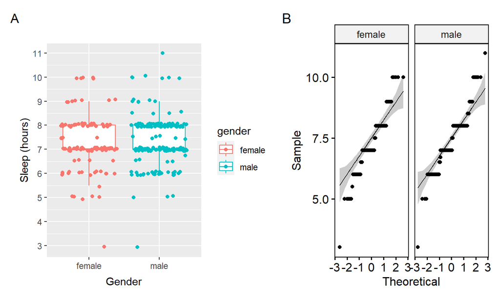

```r
# make QQ plot and Boxplot for normality
p1 <-  ggplot(gender_sleep_df,aes(x = gender, y = sleep, colour = gender)) +
  geom_boxplot(outlier.shape = NA) + #remove outliers so not confused with jitter
  geom_jitter() +
  scale_y_continuous(breaks=seq(floor(min(gender_sleep_df$sleep)),
                                ceiling(max(gender_sleep_df$sleep)), by=1)) +
  labs(y = "Sleep (hours)", x = "Gender")

p2 <-  ggqqplot(gender_sleep_df, x = "sleep", facet.by = "gender")

p1 + p2 + plot_annotation(tag_levels = 'A')
```

Figure 3. Side by side boxplots and QQ plots showing equal spread and normality if not that users round to the nearest hour

```r
res2 = t.test(males, females, alternative = "two.sided", var.equal = TRUE)
```

1. **Hypothesis:** $H_0:$ The mean of sleep in males vs females are the same vs $H_1:$ The mean of sleep in males vs females are **NOT** the same
2. **Assumptions:** Samples are independent, normally distributed (Because we have quite a large sample size, we can rely on the Central Limit Theorem for normality even though the QQ plot and histogram may look somewhat non-normal), and equal variance (Table shows variance that are somewhat close together)
3. **Test Statistic:** $T = \dfrac{{\bar X} - {\bar Y}}{S_p \sqrt{\frac{1}{n_x} + \frac{1}{n_y}}}$ where $S^2_p = \dfrac{(n_x-1) S_{x}^2 + (n_y-1) S_{y}^2}{n_x+n_y-2}$ and under, $H0:T \sim t_{n_x+n_y-2}$ Where $n_x$ = 179 and $n_y$ = 111
4. **Observed Test Statistic:** $t_0$ = 1.076
5. **P-Value:** 0.2828
6. **Decision:** Because our p-value was much larger than 0.05, there is evidence that suggest that we should retain the null hypothesis and reject the alternative hypothesis, thus saying that there is no significant difference between the mean hours of sleep for males vs females in the DATA2X02 Cohort.

### 2.3 Is there a difference between the mean hours of exercise and low vs high anxiety levels

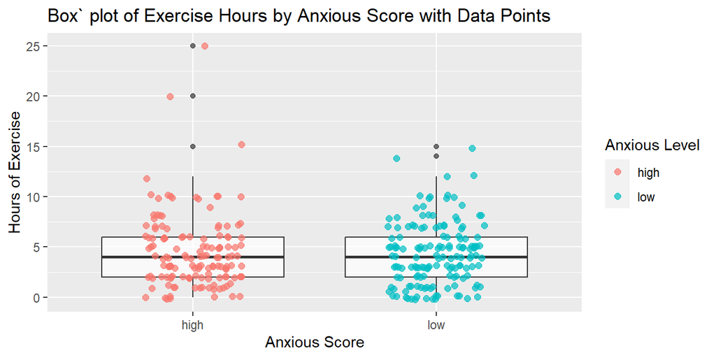

```r
ggplot(anxious_vector_df, aes(x = as.factor(anxious), y = exercise)) +
  geom_boxplot(alpha = 0.7) +  # Box plot
  geom_jitter(width = 0.2, aes(color = as.factor(anxious)), size = 2, alpha = 0.7) +  # Individual points with a little jitter to prevent overlap
  ggtitle("Box` plot of Exercise Hours by Anxious Score with Data Points") +
  xlab("Anxious Score") +
  ylab("Hours of Exercise") +
  scale_color_discrete(name = "Anxious Level")  # Color legend
```

```r
displayTable = anxious_vector_df %>% group_by(anxious) %>% summarise(
  Count = n(),
  Mean = mean(exercise) %>% signif(2),
  SD = sd(exercise) %>% signif(2)
)

knitr::kable(displayTable)
```

| anxious | Count | Mean | SD |
| --- | --- | --- | --- |
| high | 139 | 4.5 | 3.6 |
| low | 150 | 4.3 | 3.1 |

table 3. Numerical summaries consisting of count, mean, and standard deviation for hours of exercised worked in high and low groups

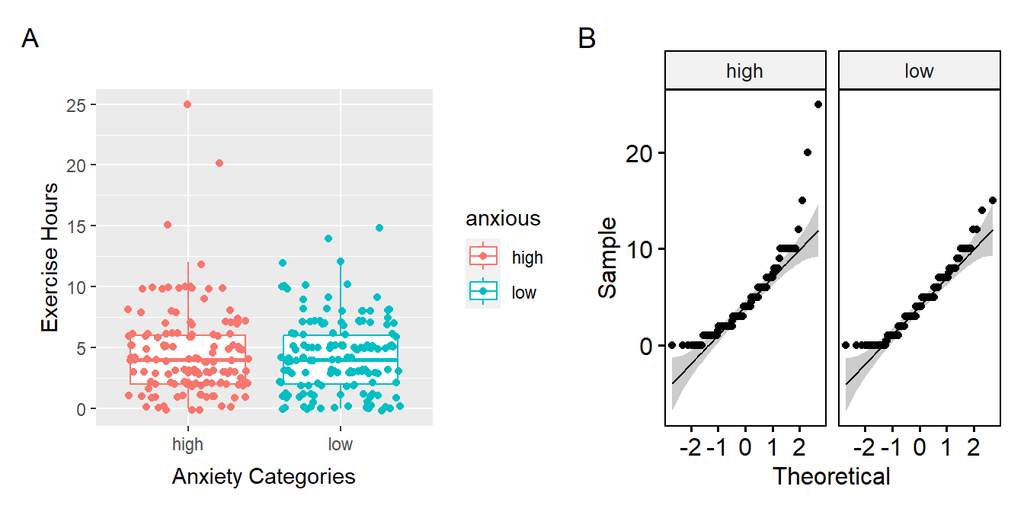

```r
p1 <-  ggplot(anxious_vector_df,aes(x = anxious, y = exercise, colour = anxious)) +
  geom_boxplot(outlier.shape = NA) + #remove outliers so not confused with jitter
  geom_jitter() +
  scale_y_continuous(breaks=seq(floor(min(anxious_vector_df$exercise)),               ceiling(max(anxious_vector_df$exercise)), by=5)) +
  labs(y = "Exercise Hours", x = "Anxiety Categories")

p2 <-  ggqqplot(anxious_vector_df, x = "exercise", facet.by = "anxious")

p1 + p2 + plot_annotation(tag_levels = 'A')
```

QQplot conveying signs of normality if our data was not rounded to the nearest half hour and boxplot showing the distributions exhibiting very equal spread across high and low categories

```r
tt = t.test(exercise ~ anxious, data = anxious_vector_df, var.equal = TRUE)
set.seed(520641008)
permuted = anxious_vector_df
B = 10000
result = vector("numeric", length = B)
for(i in 1:B){
  permuted$anxious = sample(anxious_vector_df$anxious)
  result[i] = t.test(exercise ~ anxious, data = permuted)$statistic
}

p_value = mean(abs(result) >= abs(tt$statistic))
```

1. **Hypothesis** - $H_0:$ There is no difference in the mean hours spend exercising to high and low anxiety levels vs $H_1$: There is a difference in the mean hours spend exercising to high and low anxiety levels
2. **Assumptions:** Independent observations
3. **Test Statistic:** $T = \dfrac{{\bar X} - {\bar Y}}{S_p \sqrt{\frac{1}{n_x} + \frac{1}{n_y}}}$ where $S^2_p = \dfrac{(n_x-1) S_{x}^2 + (n_y-1) S_{y}^2}{n_x+n_y-2}$ and under, $H0:T \sim t_{n_x+n_y-2}$
4. **Observed Test Statistic:** $t_0 = 0.542$
5. **P-Value:** $0.595$
6. **Decision:** Since the p-value is larger than 0.05, we retain the null hypothesis and conclude that Anxiety level and hours spent exercising among the DATA2X02 cohort are independent of each other

## 3 Conclusion

We extend our gratitude to Professor Garth Tarr for providing the survey data from the DATA2X02 Cohort this semester, which enabled a comprehensive examination of the cohort’s perspectives on specific subjects.

However, we should approach these conclusions with caution. The independence assumption of the test conducted might have been compromised due to some biases and survey : the respondents were aware that their responses could be used in a subsequent assignment, and there was no restriction on the number of submissions by a single respondent.